# Learning to risk aversion

How social learning model works in a multi-armed bandit

Wataru Toyokawa

06/01/2021

# A multi-armed bandit problem

Given a fixed time/energy budget, animals face a fundamental trade-off between exploring for better resources and exploiting known resources to optimize overall performance under uncertainty. The exploration-exploitation dilemma is well captured by a simple multi-armed bandit task, an abstract gambling situation where individuals repeatedly choose a behavioural option from a set of alternatives (see [Sutton & Barto (2020)](http://incompleteideas.net/book/the-book-2nd.html) for the concise introduction). Decision makers could learn from payoffs, but could only observe the payoff of the chosen alternative. Although the task might look overly simple, but in fact thanks to this simplicity, the task has been widely used in studying human learning behaviour.

## The hot stove effect

The bulk of introductory texts on the multi-armed bandit and reinforcement learning focus only on a risk-neutral task; that is, all behavioural alternatives had the same level of inherent uncertainty. For instance, in the 10-armed test bed ([Sutton & Barto (2020)](http://incompleteideas.net/book/the-book-2nd.html)) all the 10 options had the same s.d. values although their expected values were different. In such a risk-neutral case, reinforcement learners typically are able to choose better alternatives that produce higher expected payoff as increasing time horizon (An introductory tutorial for the 10-armed test bed is available at my [website](https://watarutoyokawa.shinyapps.io/k_armed_bandit_mini_tutorial/)).

However, nature is not that homogeneous. In reality, some behavioural options might be much noisier (i.e. risky, uncertain, or volatile) than others. When I look back my time in Sapporo, I still remember that [Bishoku-rho](https://tabelog.com/hokkaido/A0101/A010201/1007362/)[^1] occasionally fed me a stunningly delicious **杏仁豆腐** almond-jelly-ish pudding (accompanied with an unbelievable amount of steamed rice and **大学芋** deep-fried battered sweet potato with caramel (?) cause) which I loved, but its quality was so unreliable and so unpredictable that I often had to eat a bit off-flavoured ones (which I really hated). Because I couldn’t foresee how good the almond-jelly would be on the day, going to Bishoku-rho was a kind of gamble and only choice I could make was just praying to Buddha. On the other hand, another Chinese place nearby, [Shinyou-hanten](https://tabelog.com/hokkaido/A0101/A010201/1004833/), fed me a reasonable quality of almond-jelly more reliably, though its character-less taste might not be the best. Consequently, what happened eventually to me was that I increased the frequency of visiting stable Shinyo-hanten over unstable Bishoku-rho. I ostensivbly became risk-averse overtime even though on average Bishoku-rho might provided more delicious almond-jellies and deep-fried battered potato.

Such risk-aversion emerging from experience-based repeated decision-making can be well captured by reinforcement learning (March, 1996; Denrell, March, 2001; Denrell, 2007). Risk-aversion emerges due to the nature of balancing between exploration and exploitation that functions to reduce the chance of further failures once the individual has experienced an unfavourable outcome from the risky alternative, a phenomenon known as the **hot stove effect**. If a decision-maker overestimates the expected payoff of a risky alternative, he or she likely chooses it again and, due to the instability of payoff, may experience a poor outcome, reducing their belief about the quality of the risky option. On the other hand, if the decision-maker underestimates the expected payoff of the risky alternative, they may avoid it and thus have little chance to experience good outcomes. As a result, individuals may end up possessing an underestimation of risky alternative (Denrell, 2007). Risk-aversion can be suboptimal in a long run if taking risk gives higher payoffs over repeated trials on average. Therefore, although reinforcement learning seems adaptive in a wide range of risk-neutral environments, it is not necessarily adaptive under risk-heterogeneous environments.

# A step-by-step walking through of the model

The goal of this tutorial session is to introduce a basics of computational modelling and agent-based simulations. Because it is going to be a bit mathy (and messy), I have uploaded a wee slide that hopefully aids your understanding. Here is the [link](https://www.slideshare.net/WataruToyokawa1/chain-winter-school-2021-modelling-tutorial-1).

## The one-risky-one-safe armed bandit task

Assume that there are two alternatives, one is a safe alternative producing a (almost) sure payoff and the other is a risky choice producing a payoff noisily. The following histogram shows the payoff distributions for each of the alternatives (sure: yellow, risky: red).

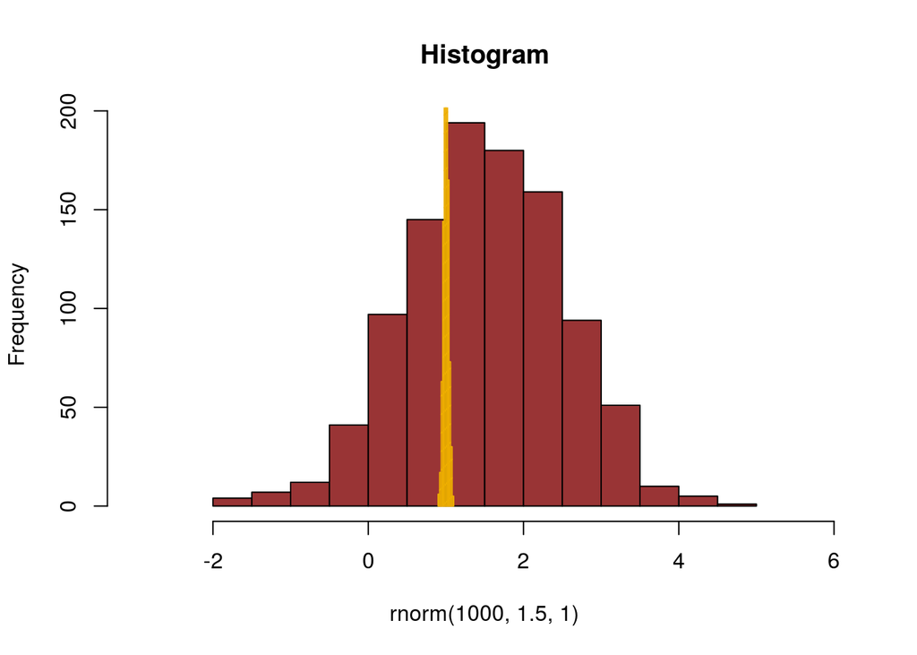

```r
hist(rnorm(1000, 1.5, 1), xlim = c(-3, 6), main="Histogram", col="#993435") # risky option
hist(rnorm(1000, 1, 0.03), density=10, col="#edae00", add = TRUE) # sure option
```

The payoff of the safe alternative follows a normal distribution with mean = 1 and s.d. = 0.03, and hence is almost certain, while that of the risky alternative follows mean = 1.5 and s.d. = 1 which varies much wider than the safe option. The risky alternative drops higher payoffs on average than the sure option; that is, about 69% more likely the risky alternative produces a larger payoff than the safe alternative.

You can explore the effects of the shape of the payoff distributions on decision-making performance through changing these parameters later. But, for now, let me stick with this simplest setting in the sake of comparability to the Illustrative Model of Denrell (2007).

Am initial step we need is

```r
# Setting our environment
set.seed(777) # setting a seed to the random process below to fix the result
repetition = 10 # number of repetition for a specific combination of alpha and beta
group_size = 5 # how many individuals there are within one simulation
# Note: repetition * groupSize determines the total number of simulation run
# in the individual learning situation. However, in the social learning model section,
# learners in the same group are interactive each other and hence not independent.
# Though the group structure does not mean anything in the current individual learning situation,
# I therefore prefer to include group here as well.

num_options = 2 # the number of options
horizon = 200 # total trial number in one session
Q_initial = 1.25 # neutral prior belief
```

Note that I set `repetition = 10` and `groupSize = 5`, which makes the total simulation runs being 50. If you fancy running more simulations, you can increase `repetition` and/or `groupSize` so as to obtain more observations.

In the 10-armed test bed of [Sutton & Barto (2020)](http://incompleteideas.net/book/the-book-2nd.html), you simulated with an environment whose global mean of payoff values was 0. However, in this example the global mean payoff is 1.25. And I assumed a neutral initial expectation (i.e. neither optimistic nor pessimistic prior expectation), hence `Q_initial = 1.25`. Again, you can explore the effect of the prior belief by changing this value. The larger the prior belief, the more exploration in the initial trials would emerge, which might improve the overall performance.

Next, we have to define the profiles of the two options as follows:

```r
# mean and s.d. values for two, sure and risky alternatives
mean_list = c(1, 1.5)
sd_list = c(0.03, 1)
```

These lists together can determine the profile of payoff distribution once `choice[t]` is made. For example, if an individual returns `choice[t] = 2` at trial `t`, the payoff will realize in accordance with:

```r
rnorm(n = 1, mean_list[2], sd_list[2])
```

```
## [1] 1.989786
```

```r
# Note: if `choice[t] = 1` instead, it should be rnorm(n = 1, mean_list[1], sd_list[1])
```

Finally, we need a list of the learning model’s parameter values that we want to investigate. Here we only consider the learning rate `alpha` (i.e. the step size parameter) and the inverse temperature of the softmax choice `beta`.

In the current setting, Denrell (2007) analytically showed that the hot stove effect leads the agent to risk-aversion when $\alpha (\beta + 1) > 2$.

```r
# parameters we will explore
alpha_list <- c(0.3, 0.5, 0.7)
beta_list <- c(2, 3, 4, 6)
```

The preparation is done. Now we will proceed to the simulation.

## Step-by-step walk through of a trial

Before launching the entire simulation run, I would like to invite you to walk through a simulation step by step.

First, we have to define each individual’s parameter values. Imagine there are 5 innocent individuals who have:

```r
alpha_base <- alpha_list[2] %>% convert_prob_to_base
(this_alpha <- (alpha_base + rnorm(group_size, 0, 0.05)) %>% convert_base_to_prob)
```

```
## [1] 0.4950184 0.5063851 0.4950150 0.5204721 0.5077653
```

```r
(this_beta <- beta_list[2] + rnorm(group_size, 0, 0.05))
```

```
## [1] 3.010135 3.055447 2.989689 2.981052 2.984787
```

I assumed that there are (small) individual differences in both learning parameters. It was not necessary for now, as we are not really interested in the effect of individual variation. However, in the future we will use those variations for a parameter recovery test. So why don’t we already let them vary a bit.

Now we have five agents. Their goal is to maximize total payoff they earn over the limited time `horizon = 200`. They have no prior experience in this task, but they have somehow known that the overall expectation from this environment is `Q_initial = 1.25` (maybe their physiology has already been tuned through genetic evolution).

```r
# The initial status of the five innocent participants
Q <- array(dim = c(num_options, horizon, group_size))
Q[,1,] <- Q_initial # Q_initial = 1.25
```

Alright, the initial setup is done. By now, each individual has the initial behavioural value (“Q value”) for each risky and safe alternative. For example, the individual 1’s Q-values at the moment looks like:

```r
Q[, 1:12, 1:2]
```

```
## , , 1
##
##      [,1] [,2] [,3] [,4] [,5] [,6] [,7] [,8] [,9] [,10] [,11] [,12]
## [1,] 1.25   NA   NA   NA   NA   NA   NA   NA   NA    NA    NA    NA
## [2,] 1.25   NA   NA   NA   NA   NA   NA   NA   NA    NA    NA    NA
##
## , , 2
##
##      [,1] [,2] [,3] [,4] [,5] [,6] [,7] [,8] [,9] [,10] [,11] [,12]
## [1,] 1.25   NA   NA   NA   NA   NA   NA   NA   NA    NA    NA    NA
## [2,] 1.25   NA   NA   NA   NA   NA   NA   NA   NA    NA    NA    NA
```

Similarly, we need to set the initial probability of choosing each of the alternatives. I assume that there is no inherent bias, so choosing either of the options is 50-50 chance.

```r
netChoiceProb <- array(dim = c(num_options, horizon, group_size))
netChoiceProb[,1,] <- 1/num_options
netChoiceProb[,1:12,1]
```

```
##      [,1] [,2] [,3] [,4] [,5] [,6] [,7] [,8] [,9] [,10] [,11] [,12]
## [1,]  0.5   NA   NA   NA   NA   NA   NA   NA   NA    NA    NA    NA
## [2,]  0.5   NA   NA   NA   NA   NA   NA   NA   NA    NA    NA    NA
```

Additionally, we need more of such `NA` containers in which the individual behaviour will be recorded. These are:

```r
choices <- matrix(nrow=group_size, ncol=horizon)
payoffs <- matrix(nrow=group_size, ncol=horizon)
riskyChoiceProb <- matrix(nrow=group_size, ncol=horizon)
```

These empty matrices are `group_size` * `horizon` matrices:

```r
choices[, 1:12]
```

```
##      [,1] [,2] [,3] [,4] [,5] [,6] [,7] [,8] [,9] [,10] [,11] [,12]
## [1,]   NA   NA   NA   NA   NA   NA   NA   NA   NA    NA    NA    NA
## [2,]   NA   NA   NA   NA   NA   NA   NA   NA   NA    NA    NA    NA
## [3,]   NA   NA   NA   NA   NA   NA   NA   NA   NA    NA    NA    NA
## [4,]   NA   NA   NA   NA   NA   NA   NA   NA   NA    NA    NA    NA
## [5,]   NA   NA   NA   NA   NA   NA   NA   NA   NA    NA    NA    NA
```

```r
payoffs[, 1:12]
```

```
##      [,1] [,2] [,3] [,4] [,5] [,6] [,7] [,8] [,9] [,10] [,11] [,12]
## [1,]   NA   NA   NA   NA   NA   NA   NA   NA   NA    NA    NA    NA
## [2,]   NA   NA   NA   NA   NA   NA   NA   NA   NA    NA    NA    NA
## [3,]   NA   NA   NA   NA   NA   NA   NA   NA   NA    NA    NA    NA
## [4,]   NA   NA   NA   NA   NA   NA   NA   NA   NA    NA    NA    NA
## [5,]   NA   NA   NA   NA   NA   NA   NA   NA   NA    NA    NA    NA
```

```r
riskyChoiceProb[, 1:12]
```

```
##      [,1] [,2] [,3] [,4] [,5] [,6] [,7] [,8] [,9] [,10] [,11] [,12]
## [1,]   NA   NA   NA   NA   NA   NA   NA   NA   NA    NA    NA    NA
## [2,]   NA   NA   NA   NA   NA   NA   NA   NA   NA    NA    NA    NA
## [3,]   NA   NA   NA   NA   NA   NA   NA   NA   NA    NA    NA    NA
## [4,]   NA   NA   NA   NA   NA   NA   NA   NA   NA    NA    NA    NA
## [5,]   NA   NA   NA   NA   NA   NA   NA   NA   NA    NA    NA    NA
```

### The first trial

Well done. We have thus far defined the 5 innocent individuals as well as a few containers where behavioural trajectories of these individuals will be recorded. We can finally start a simulation. The first trial starts by setting `t <- 1`:

```r
t <- 1
```

The session started. Five naive participants have entered to a gloomy cold chamber of psychology experimental laboratory[^2], and now they are facing each computer’s monitor showing two different slot machines from which they have to make a choice. So let’s get started.

#### Make a choice

```r
# each individual chooses one option based on his/her choice probability netChoiceProb[,t,]
choices[,t] <- apply(netChoiceProb[,t,]
                     , MARGIN = 2
                     , function(netChoiceProbInstance){
                                sample(1:num_options
                                       , 1
                                       , prob=netChoiceProbInstance
                                       , replace=FALSE
                                )
                       }
                        )
```

It may look a bit scary at a first glance. But what’s done here is only that each individual samples a value from a vector `1:num_options` randomly with its probability determined by `netChoiceProb[,t,]`. As a result, the choices are determined:

```r
choices[,t]
```

```
## [1] 1 2 2 1 2
```

#### Get a payoff

They have pulled the slot’s lever down. Naturally, the next step is getting payoffs.

```r
# each subject earns payoffs whose amount depends upon choices[,t]
payoffs[,t] <- mapply(rnorm, 1, mean_list[choices[,t]], sd_list[choices[,t]])
payoffs[,t]
```

```
## [1] 1.004424 2.030062 2.103139 0.986851 1.001210
```

Note that individuals who chose option 1 might get payoff nearly 1, whereas those who chose the risky option might get a huge bonanza or very low payoff because of its larger noise.

#### Rescorla-Wagner Updating

The participants who were initially innocent and naive have obtained by now a small piece of information from their own choices. The next step is to update their inner belief by the Rescorla-Wagner rule:

```r
# Rescorla-Wagner updating rule: Q_next <- Q + alpha * (payoff - Q)
# rescorla_wagner_updating() function is defined in a separated file 'functions.R'
Q <- rescorla_wagner_updating(t
                             , numoptions
                             , group_size
                             , horizon
                             , this_alpha
                             , choices[,t]
                             , payoffs[,t]
                             , Q
                             )
# Example of three individuals' Q values
Q[,1:8,1:5]
```

```
## , , 1
##
##      [,1]     [,2] [,3] [,4] [,5] [,6] [,7] [,8]
## [1,] 1.25 1.128435   NA   NA   NA   NA   NA   NA
## [2,] 1.25 1.250000   NA   NA   NA   NA   NA   NA
##
## , , 2
##
##      [,1]     [,2] [,3] [,4] [,5] [,6] [,7] [,8]
## [1,] 1.25 1.250000   NA   NA   NA   NA   NA   NA
## [2,] 1.25 1.645012   NA   NA   NA   NA   NA   NA
##
## , , 3
##
##      [,1]     [,2] [,3] [,4] [,5] [,6] [,7] [,8]
## [1,] 1.25 1.250000   NA   NA   NA   NA   NA   NA
## [2,] 1.25 1.672317   NA   NA   NA   NA   NA   NA
##
## , , 4
##
##      [,1]     [,2] [,3] [,4] [,5] [,6] [,7] [,8]
## [1,] 1.25 1.113038   NA   NA   NA   NA   NA   NA
## [2,] 1.25 1.250000   NA   NA   NA   NA   NA   NA
##
## , , 5
##
##      [,1]     [,2] [,3] [,4] [,5] [,6] [,7] [,8]
## [1,] 1.25 1.250000   NA   NA   NA   NA   NA   NA
## [2,] 1.25 1.123673   NA   NA   NA   NA   NA   NA
```

Q-value was updated. To see what happened, let’s focus on the first individual. His (or her) first choice and payoff were

```r
choices[1,t] # the first individual's choice made at trial t
```

```
## [1] 1
```

```r
payoffs[1,t] # the first individual's payoff obtained at trial t
```

```
## [1] 1.004424
```

His learning rate $\alpha$ was:

```r
this_alpha[1]
```

```
## [1] 0.4950184
```

Therefore, according to the Rescorla-Wagner rule, his new Q-value should look like:

```r
1.25 + this_alpha[1] * (payoffs[1,t] - 1.25) # Rescorla-Wagner updating
```

```
## [1] 1.128435
```

Let’s check how it actually looks like. The first individual’s Q value is:

```r
Q[,1:10,1]
```

```
##      [,1]     [,2] [,3] [,4] [,5] [,6] [,7] [,8] [,9] [,10]
## [1,] 1.25 1.128435   NA   NA   NA   NA   NA   NA   NA    NA
## [2,] 1.25 1.250000   NA   NA   NA   NA   NA   NA   NA    NA
```

#### Softmax (multinomial-logistic) choice

Based on the new `Q` values, individuals’ probability of choosing each option can be calculated by softmax function:

```r
###############
## Softmax choice base solely on Q values
###############
# Calculate each "exp( beta*Q_i )"
Q_exp = ( Q[,t+1,] * rep(this_beta, each = num_options) ) %>% exp()
# Then, calculating the softmax probability
# exp( beta*Q_k )/(exp( beta*Q_1 ) + exp( beta*Q_2 )) for each slot
softmaxMatrix = Q_exp %>%
  apply(MARGIN=1, divideVector, denominator = apply(Q_exp, MARGIN=2, sum)) %>%
  t()
## The followings update the choice probability matrix
###############
## Softmax -- END
###############
```

```r
softmaxMatrix
```

```
##           [,1]      [,2]      [,3]      [,4]      [,5]
## [1,] 0.4095258 0.2302433 0.2205274 0.3993222 0.5931635
## [2,] 0.5904742 0.7697567 0.7794726 0.6006778 0.4068365
```

```r
# This chunk does a messy transformations of matrices
# The main idea is that each column of 'softmaxMatrix' is separately recorded
# in 'netChoiceProb' list
netChoiceProbAperm = aperm(netChoiceProb, c(1,3,2))
dim(netChoiceProbAperm) = c(num_options*group_size, horizon)
dim(softmaxMatrix) = c(num_options*group_size, 1)
netChoiceProbAperm[,t+1] = softmaxMatrix
dim(netChoiceProbAperm) = c(num_options, group_size, horizon)
netChoiceProb = aperm(netChoiceProbAperm, c(1,3,2))
# The end of mess

# Updated choice probabilities for each individual
netChoiceProb[,1:12,1:5]
```

```
## , , 1
##
##      [,1]      [,2] [,3] [,4] [,5] [,6] [,7] [,8] [,9] [,10] [,11] [,12]
## [1,]  0.5 0.4095258   NA   NA   NA   NA   NA   NA   NA    NA    NA    NA
## [2,]  0.5 0.5904742   NA   NA   NA   NA   NA   NA   NA    NA    NA    NA
##
## , , 2
##
##      [,1]      [,2] [,3] [,4] [,5] [,6] [,7] [,8] [,9] [,10] [,11] [,12]
## [1,]  0.5 0.2302433   NA   NA   NA   NA   NA   NA   NA    NA    NA    NA
## [2,]  0.5 0.7697567   NA   NA   NA   NA   NA   NA   NA    NA    NA    NA
##
## , , 3
##
##      [,1]      [,2] [,3] [,4] [,5] [,6] [,7] [,8] [,9] [,10] [,11] [,12]
## [1,]  0.5 0.2205274   NA   NA   NA   NA   NA   NA   NA    NA    NA    NA
## [2,]  0.5 0.7794726   NA   NA   NA   NA   NA   NA   NA    NA    NA    NA
##
## , , 4
##
##      [,1]      [,2] [,3] [,4] [,5] [,6] [,7] [,8] [,9] [,10] [,11] [,12]
## [1,]  0.5 0.3993222   NA   NA   NA   NA   NA   NA   NA    NA    NA    NA
## [2,]  0.5 0.6006778   NA   NA   NA   NA   NA   NA   NA    NA    NA    NA
##
## , , 5
##
##      [,1]      [,2] [,3] [,4] [,5] [,6] [,7] [,8] [,9] [,10] [,11] [,12]
## [1,]  0.5 0.5931635   NA   NA   NA   NA   NA   NA   NA    NA    NA    NA
## [2,]  0.5 0.4068365   NA   NA   NA   NA   NA   NA   NA    NA    NA    NA
```

### The second trial

```r
t <- 2
```

```r
# each individual chooses one option based on his/her choice probability netChoiceProb[,t,]
choices[,t] <- apply(netChoiceProb[,t,]
                     , MARGIN = 2
                     , function(netChoiceProbInstance){
                                sample(1:num_options
                                       , 1
                                       , prob=netChoiceProbInstance
                                       , replace=FALSE
                                )
                       }
                        )

# each subject earns payoffs whose amount depends upon choices[,t]
payoffs[,t] <- mapply(rnorm, 1, mean_list[choices[,t]], sd_list[choices[,t]])

# Rescorla-Wagner updating rule: Q_next <- Q + alpha * (payoff - Q)
Q <- rescorla_wagner_updating(t
                             , numoptions
                             , group_size
                             , horizon
                             , this_alpha
                             , choices[,t]
                             , payoffs[,t]
                             , Q
                             )

###############
## Softmax choice base solely on Q values
###############
# Calculate each "exp( beta*Q_i )"
Q_exp = ( Q[,t+1,] * rep(this_beta, each = num_options) ) %>% exp()
# Then, calculating the softmax probability
# exp( beta*Q_k )/(exp( beta*Q_1 ) + exp( beta*Q_2 )) for each slot
softmaxMatrix = Q_exp %>%
  apply(MARGIN=1, divideVector, denominator = apply(Q_exp, MARGIN=2, sum)) %>%
  t()
## The followings update the choice probability matrix
###############
## Softmax -- END
###############

netChoiceProbAperm = aperm(netChoiceProb, c(1,3,2))
dim(netChoiceProbAperm) = c(num_options*group_size, horizon)
dim(softmaxMatrix) = c(num_options*group_size, 1)
netChoiceProbAperm[,t+1] = softmaxMatrix
dim(netChoiceProbAperm) = c(num_options, group_size, horizon)
netChoiceProb = aperm(netChoiceProbAperm, c(1,3,2))
```

```r
choices[,t]
```

```
## [1] 2 2 2 2 1
```

```r
payoffs[,t]
```

```
## [1] 1.7277519 0.7169749 2.7735921 2.9377107 1.0128103
```

```r
netChoiceProb[,1:12,1:5]
```

```
## , , 1
##
##      [,1]      [,2]      [,3] [,4] [,5] [,6] [,7] [,8] [,9] [,10] [,11] [,12]
## [1,]  0.5 0.4095258 0.2539205   NA   NA   NA   NA   NA   NA    NA    NA    NA
## [2,]  0.5 0.5904742 0.7460795   NA   NA   NA   NA   NA   NA    NA    NA    NA
##
## , , 2
##
##      [,1]      [,2]      [,3] [,4] [,5] [,6] [,7] [,8] [,9] [,10] [,11] [,12]
## [1,]  0.5 0.2302433 0.5569891   NA   NA   NA   NA   NA   NA    NA    NA    NA
## [2,]  0.5 0.7697567 0.4430109   NA   NA   NA   NA   NA   NA    NA    NA    NA
##
## , , 3
##
##      [,1]      [,2]       [,3] [,4] [,5] [,6] [,7] [,8] [,9] [,10] [,11] [,12]
## [1,]  0.5 0.2205274 0.05252965   NA   NA   NA   NA   NA   NA    NA    NA    NA
## [2,]  0.5 0.7794726 0.94747035   NA   NA   NA   NA   NA   NA    NA    NA    NA
##
## , , 4
##
##      [,1]      [,2]       [,3] [,4] [,5] [,6] [,7] [,8] [,9] [,10] [,11] [,12]
## [1,]  0.5 0.3993222 0.04622686   NA   NA   NA   NA   NA   NA    NA    NA    NA
## [2,]  0.5 0.6006778 0.95377314   NA   NA   NA   NA   NA   NA    NA    NA    NA
##
## , , 5
##
##      [,1]      [,2]      [,3] [,4] [,5] [,6] [,7] [,8] [,9] [,10] [,11] [,12]
## [1,]  0.5 0.5931635 0.5043951   NA   NA   NA   NA   NA   NA    NA    NA    NA
## [2,]  0.5 0.4068365 0.4956049   NA   NA   NA   NA   NA   NA    NA    NA    NA
```

## Run an entire session

```r
group_size = 20

# individual parameters
alpha_base <- convert_prob_to_base(alpha_list[2])
this_alpha <- (alpha_base + rnorm(group_size, 0, 0.05)) %>% convert_base_to_prob
this_beta <- beta_list[3] + rnorm(group_size, 0, 0.05)

# The initial status of the five innocent participants
Q <- array(dim = c(num_options, horizon, group_size))
Q[,1,] <- Q_initial # Q_initial = 1.25
netChoiceProb <- array(dim = c(num_options, horizon, group_size))
netChoiceProb[,1,] <- 1/num_options
choices <- matrix(nrow=group_size, ncol=horizon)
payoffs <- matrix(nrow=group_size, ncol=horizon)
riskyChoiceProb <- matrix(nrow=group_size, ncol=horizon)

for (t in 1:horizon) {
  # each individual chooses one option based on his/her choice probability netChoiceProb[,t,]
  choices[,t] <- apply(netChoiceProb[,t,]
                       , MARGIN = 2
                       , function(netChoiceProbInstance){
                                sample(1:num_options
                                       , 1
                                       , prob=netChoiceProbInstance
                                       , replace=FALSE
                                )
                         }
                        )

  # each subject earns payoffs whose amount depends upon choices[,t]
  payoffs[,t] <- mapply(rnorm, 1, mean_list[choices[,t]], sd_list[choices[,t]])

  if (t < horizon) {
    # Rescorla-Wagner updating rule: Q_next <- Q + alpha * (payoff - Q)
    Q <- rescorla_wagner_updating(t
                                 , numoptions
                                 , group_size
                                 , horizon
                                 , this_alpha
                                 , choices[,t]
                                 , payoffs[,t]
                                 , Q
                                 )


    ###############
    ## Softmax choice base solely on Q values
    ###############
    # Calculate each "exp( beta*Q_i )"
    Q_exp = ( Q[,t+1,] * rep(this_beta, each = num_options) ) %>% exp()
    # Then, calculating the softmax probability
    # exp( beta*Q_k )/(exp( beta*Q_1 ) + exp( beta*Q_2 )) for each slot
    softmaxMatrix = Q_exp %>%
      apply(MARGIN=1, divideVector, denominator = apply(Q_exp, MARGIN=2, sum)) %>%
      t()
    ## The followings update the choice probability matrix
    ###############
    ## Softmax -- END
    ###############

    netChoiceProbAperm = aperm(netChoiceProb, c(1,3,2))
    dim(netChoiceProbAperm) = c(num_options*group_size, horizon)
    dim(softmaxMatrix) = c(num_options*group_size, 1)
    netChoiceProbAperm[,t+1] = softmaxMatrix
    dim(netChoiceProbAperm) = c(num_options, group_size, horizon)
    netChoiceProb = aperm(netChoiceProbAperm, c(1,3,2))
  }
}
# Hooooray! One simulation run is done by now.
# Next, we need to record this result
# First, let's summarise this run:
for(i in 1:group_size) {
   riskyChoiceProb[i,] <- netChoiceProb[2,,i]
}
```

### Result of this session

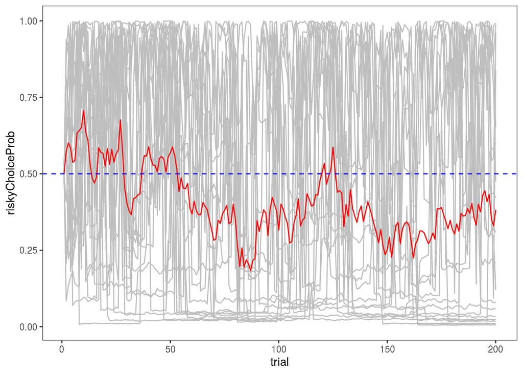

```r
thisGroup <- as.data.frame(riskyChoiceProb) %>%
  cbind(data.frame(indiv = 1:group_size)) %>%
  tidyr::pivot_longer(-indiv, names_to='names', values_to='riskyChoiceProb')
thisGroup$trial <- rep(1:horizon, group_size)

thisGroup %>%
  ggplot() +
  geom_line(aes(trial, riskyChoiceProb, group = indiv), colour='grey') +
  stat_summary(aes(trial, riskyChoiceProb), fun='mean', geom='line', color='red')+
  geom_hline(yintercept = 0.5, linetype = 'dashed', colour = 'blue')+
  theme_test()
```

## A whole simulation experiment

The simulation will actually look like this:

```r
for (alpha in alpha_list) {
  for (beta in beta_list) {
    for (r in 1:repetition) {
      # == This is where we should write a simulated session ==
      # There will be four steps:
      # 1. determine individual parameters
      # 2. a group of individuals play the bandit task
      # 3. record the result (the end of the session)
      # 4. go back to 1 until "r" reaches to "repetition"
      # ...
      # Note: Three loops of "for(){}" are nested.
      # First, the outermost for() picks one alpha value from alpha_list
      # Then, under the given alpha value, one beta value is picked from beta_list
      # Finally, under these specified parameter values, totally "repetition" of simulations are run
      # ...
    }
  }
}
```

Next, though it is not really important, I prefer to make an empty `data.frame` in advance, in which simulation data will be recorded.

```r
# An empty data frame in which the data will be recorded
# Note: rep(vector, times, each) means that repeating each contents of vector 'each' times,
# then repeating this whole process 'times' times.
two_armed_bandit_data <-
  data.frame(beta = rep(beta_list, times = 1, each = length(alpha_list)*repetition*horizon)
           , alpha = rep(alpha_list, times = length(beta_list), each = repetition*horizon)
           , r = rep(1:repetition, times = length(beta_list)*length(alpha_list), each = horizon)
           , t = rep(1:horizon, times = length(beta_list)*length(alpha_list)*repetition, each = 1)
           , riskyChoiceProb = rep(NA, length(beta_list)*length(alpha_list)*repetition*horizon)
           , averageReward = rep(NA, length(beta_list)*length(alpha_list)*repetition*horizon)
           )
```

```r
for (alpha in alpha_list) {
  for (beta in beta_list) {
    for (r in 1:repetition) {
      # individual parameters
      alpha_base <- convert_prob_to_base(alpha)
      this_alpha <- (alpha_base + rnorm(group_size, 0, 0.05)) %>% convert_base_to_prob
      this_beta <- beta + rnorm(group_size, 0, 0.05)

      # The initial status of the five innocent participants
      Q <- array(dim = c(num_options, horizon, group_size))
      Q[,1,] <- Q_initial # Q_initial = 1.25
      netChoiceProb <- array(dim = c(num_options, horizon, group_size))
      netChoiceProb[,1,] <- 1/num_options
      choices <- matrix(nrow=group_size, ncol=horizon)
      payoffs <- matrix(nrow=group_size, ncol=horizon)
      riskyChoiceProb <- matrix(nrow=group_size, ncol=horizon)

      for (t in 1:horizon) {
        # each individual chooses one option
        choices[,t] <- apply(netChoiceProb[,t,]
                             , MARGIN = 2
                             , function(netChoiceProbInstance){
                                        sample(1:num_options
                                               , 1
                                               , prob=netChoiceProbInstance
                                               , replace=FALSE
                                        )
                               }
                                )

        # each subject earns payoffs whose amount depends upon choices[,t]
        payoffs[,t] <- mapply(rnorm, 1, mean_list[choices[,t]], sd_list[choices[,t]])

        if (t < horizon) {
          # Rescorla-Wagner updating rule: Q_next <- Q + alpha * (payoff - Q)
          Q <- rescorla_wagner_updating(t
                                       , numoptions
                                       , group_size
                                       , horizon
                                       , this_alpha
                                       , choices[,t]
                                       , payoffs[,t]
                                       , Q
                                       )

          ###############
          ## Softmax choice base solely on Q values
          ###############
          # Calculate each "exp( beta*Q_i )"
          Q_exp = ( Q[,t+1,] * rep(this_beta, each = num_options) ) %>% exp()
          # Then, calculating the softmax probability
          # exp( beta*Q_k )/(exp( beta*Q_1 ) + exp( beta*Q_2 )) for each slot
          softmaxMatrix = Q_exp %>%
            apply(MARGIN=1, divideVector, denominator = apply(Q_exp, MARGIN=2, sum)) %>%
            t()
          ## The followings update the choice probability matrix
          ###############
          ## Softmax -- END
          ###############

          netChoiceProbAperm = aperm(netChoiceProb, c(1,3,2))
          dim(netChoiceProbAperm) = c(num_options*group_size, horizon)
          dim(softmaxMatrix) = c(num_options*group_size, 1)
          netChoiceProbAperm[,t+1] = softmaxMatrix
          dim(netChoiceProbAperm) = c(num_options, group_size, horizon)
          netChoiceProb = aperm(netChoiceProbAperm, c(1,3,2))
        }
      }
      # ==========================================================
      # Hooooray! One simulation run is done by now.
      # Next, we need to record this result
      # First, let's summarise this run:
      for(i in 1:group_size) {
         riskyChoiceProb[i,] <- netChoiceProb[2,,i]
      }
        thisGroupPerformance = apply(riskyChoiceProb, MARGIN = 2, mean)
        thisGroupPayoff = apply(payoffs, MARGIN = 2, mean)
        # Second, let's record this in the data set you defined
        # We first find a position where new data should be recorded
        positionOfThisRun = which(two_armed_bandit_data$beta == beta &
                                    two_armed_bandit_data$alpha == alpha &
                                    two_armed_bandit_data$r == r)
        # Then, record it:
        two_armed_bandit_data$riskyChoiceProb[positionOfThisRun] = thisGroupPerformance
        two_armed_bandit_data$averageReward[positionOfThisRun] = thisGroupPayoff
        # END
        # ==========================================================
    }
  }
}
```

### Result and plot

Well done! The simulation was all done.

```r
head(two_armed_bandit_data)
```

```
##   beta alpha r t riskyChoiceProb averageReward
## 1    2   0.3 1 1       0.5000000      1.381043
## 2    2   0.3 1 2       0.5572267      1.269451
## 3    2   0.3 1 3       0.5915969      1.329910
## 4    2   0.3 1 4       0.6092433      1.220988
## 5    2   0.3 1 5       0.6043256      1.345148
## 6    2   0.3 1 6       0.6448310      1.213056
```

```r
# Let's make the summarised version of the data set
two_armed_bandit_data_summarised <- two_armed_bandit_data %>%
  # the new dataset is copied from the original dataset
  dplyr::group_by(alpha, beta, t) %>%
  summarise( # summarising the data set with the group structure considered.
    # the following two become new variables
    riskyChoiceProb_globalMean = mean(riskyChoiceProb),
    averageReward_globalMean = mean(averageReward)
    )
head(two_armed_bandit_data_summarised)
```

```
## # A tibble: 6 x 5
## # Groups:   alpha, beta [1]
##   alpha  beta     t riskyChoiceProb_globalMean averageReward_globalMean
##   <dbl> <dbl> <int>                      <dbl>                    <dbl>
## 1   0.3     2     1                      0.5                       1.23
## 2   0.3     2     2                      0.532                     1.25
## 3   0.3     2     3                      0.557                     1.17
## 4   0.3     2     4                      0.561                     1.33
## 5   0.3     2     5                      0.583                     1.27
## 6   0.3     2     6                      0.595                     1.20
```

Let’s simply make a line plot using this summarised data set:

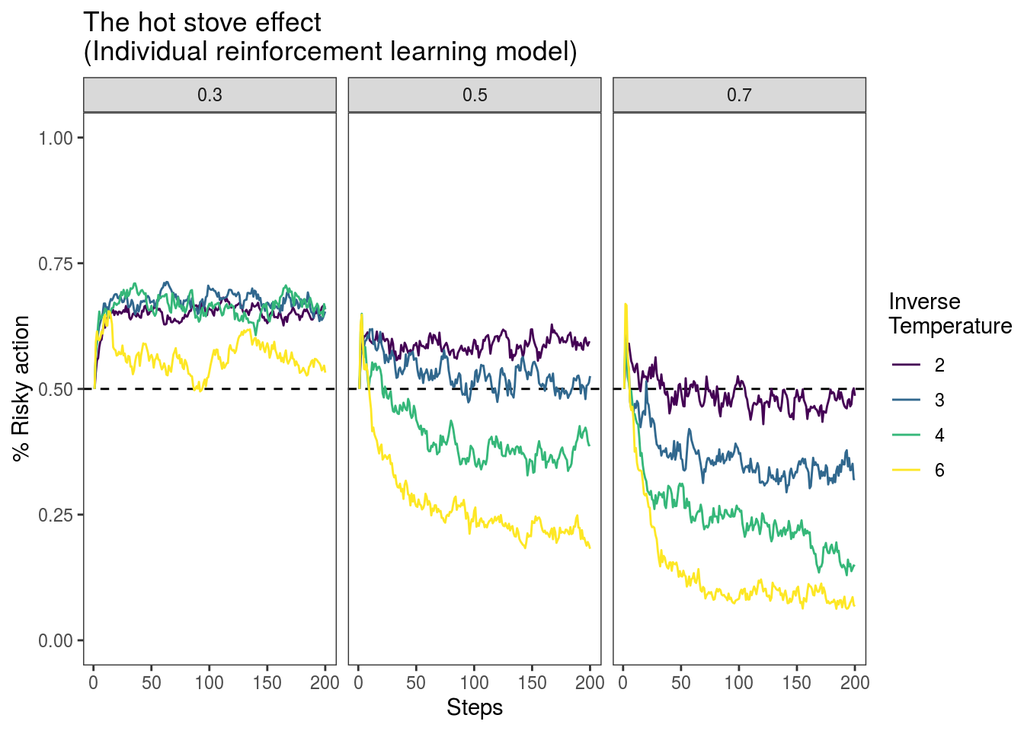

```r
(two_armed_bandit_data_summarised %>%
  ggplot() +
  geom_hline(yintercept = 0.5, linetype = 'dashed') +
  geom_line(aes(t, riskyChoiceProb_globalMean, colour = as.factor(beta))) +
  scale_colour_viridis_d() +
  ylim(c(0,1))+
  labs(x = 'Steps'
       , y = '% Risky action'
       , colour = 'Inverse\nTemperature'
       , title = 'The hot stove effect \n(Individual reinforcement learning model)') +
  facet_grid(. ~ alpha) +
  theme_test() +
  NULL -> riskyChoiceProb_plot)
```

# Social learning model

Thus far, we have assumed that individuals make a decision independently from each other. But what if they can observe others behaviour? In this section, I am going to describe one of the social learning strategies that can easily be implemented in the baseline model shown above.

Social learning (or social influences) modelled here is one of the “decision-biasing” processes (e.g. [Najar et al. 2020](https://journals.plos.org/plosbiology/article?id=10.1371/journal.pbio.3001028))[^3] where social information affects the action-selection by:

$P_{i, t+1} = (1 - \sigma) \frac{\exp(\beta Q_{i,t})}{\sum \exp(\beta Q_{k,t})} + \sigma \frac{N_{i, t}^\theta}{\sum N_{k, t}^\theta}$.

$\sigma$ is the copying weight and $\theta$ is the conformity exponent (McElreath et al. 2005; 2008; Aplin et al. 2018; Toyokawa et al. 2019; 2021; Deffner, et al. 2020).

It is quite simple. What we only need to do is (1) adding two social learning parameters $\sigma$ and $\theta$, then (2) modifying the choice probability calculation.

## Social learning simulation

```r
# An empty data frame in which the data will be recorded
social_learning_model_data <-
  data.frame(beta = rep(beta_list, times = 1, each = length(alpha_list)*repetition*horizon)
           , alpha = rep(alpha_list, times = length(beta_list), each = repetition*horizon)
           , r = rep(1:repetition, times = length(beta_list)*length(alpha_list), each = horizon)
           , t = rep(1:horizon, times = length(beta_list)*length(alpha_list)*repetition, each = 1)
           , riskyChoiceProb = rep(NA, length(beta_list)*length(alpha_list)*repetition*horizon)
           , averageReward = rep(NA, length(beta_list)*length(alpha_list)*repetition*horizon)
           )

# Social learning parameters
sigma <- 0.3 # the copying weight
theta <- 3 # the conformity exponent

# Simulation (basically identical to the individual learning model)
# The changes from the baseline model are highlighted
for (alpha in alpha_list) {
  for (beta in beta_list) {
    for (r in 1:repetition) {

      # Setting individual learning parameters
      alpha_base <- convert_prob_to_base(alpha)
      this_alpha <- (alpha_base + rnorm(group_size, 0, 0.05)) %>% convert_base_to_prob
      this_beta <- beta + rnorm(group_size, 0, 0.05)

      # -------- Social learning parameters --------------
      sigma_base <- convert_prob_to_base(sigma)
      this_sigma <- (sigma_base + rnorm(group_size, 0, 0.05)) %>% convert_base_to_prob
      this_theta <- theta + rnorm(group_size, 0, 0.05)
      # --------------------------------------------------

      # The initial settings
      Q <- array(dim = c(num_options, horizon, group_size))
      Q[,1,] <- Q_initial # Q_initial = 1.25
      netChoiceProb <- array(dim = c(num_options, horizon, group_size))
      netChoiceProb[,1,] <- 1/num_options
      choices <- matrix(nrow=group_size, ncol=horizon)
      payoffs <- matrix(nrow=group_size, ncol=horizon)
      riskyChoiceProb <- matrix(nrow=group_size, ncol=horizon)

      # -- A matrix tracking the social frequency information ----
      socialFrequency = matrix(nrow=num_options, ncol=horizon)
            socialFrequency[,] = 1e-1
            # ----------------------------------------------------------

            # A session starts for t in 1 : horizon
      for (t in 1:horizon) {
        # each individual chooses one option
        choices[,t] <- apply(netChoiceProb[,t,]
                             , MARGIN = 2
                             , function(netChoiceProbInstance){
                                        sample(1:num_options
                                               , 1
                                               , prob=netChoiceProbInstance
                                               , replace=FALSE
                                        )
                               }
                                )

        # each subject earns payoffs whose amount depends upon choices[,t]
        payoffs[,t] <- mapply(rnorm, 1, mean_list[choices[,t]], sd_list[choices[,t]])

        if (t < horizon) {
          # Rescorla-Wagner updating
          Q <- rescorla_wagner_updating(t
                                       , numoptions
                                       , group_size
                                       , horizon
                                       , this_alpha
                                       , choices[,t]
                                       , payoffs[,t]
                                       , Q
                                       )

          # ------------ Update socialFrequency ----------
                    for (k in 1:num_options) {
                      if(length(which(names(table(choices[,t]))==k))>0) {
                                socialFrequency[k,t+1] <-
                                  socialFrequency[k,t+1] +
                                  table(choices[,t])[which(names(table(choices[,t]))==k)][1]
                            }
                    }
          # ---------------------------------------------


          # Calculate each "exp( beta*Q_i )"
          Q_exp = ( Q[,t+1,] * rep(this_beta, each = num_options) ) %>% exp()
          # Then, calculating the softmax probability
          # exp( beta*Q_k )/(exp( beta*Q_1 ) + exp( beta*Q_2 )) for each slot
          softmaxMatrix = Q_exp %>%
            apply(MARGIN=1
                  , divideVector
                  , denominator = apply(Q_exp, MARGIN=2, sum)
                  ) %>%
            t()

          # ------ Calculating the social influence --------
          # The function "frequencyDependentCopy" is defined in
          # "functions.R" file
          freqDepenMatrix <-
            frequencyDependentCopy(socialFrequency[,t+1]
                                   , choices[,t]
                                   , this_theta
                                   , num_options
                                   )

          netMatrix <-
            apply(softmaxMatrix, 1, multiplying, A=(1-this_sigma)) %>%
            t() +
            apply(freqDepenMatrix, 1, multiplying, A=this_sigma) %>%
            t()
          # ------------------------------------------------

          netChoiceProbAperm = aperm(netChoiceProb, c(1,3,2))
          dim(netChoiceProbAperm) = c(num_options*group_size, horizon)
          dim(netMatrix) = c(num_options*group_size, 1)
          netChoiceProbAperm[,t+1] = netMatrix
          dim(netChoiceProbAperm) = c(num_options, group_size, horizon)
          netChoiceProb = aperm(netChoiceProbAperm, c(1,3,2))
        }
      }
      # ==========================================================
      # Hooooray! One simulation run is done by now.
      # Next, we need to record this result
      # First, let's summarise this run:
      for(i in 1:group_size) {
         riskyChoiceProb[i,] <- netChoiceProb[2,,i]
      }
        thisGroupPerformance = apply(riskyChoiceProb, MARGIN = 2, mean)
        thisGroupPayoff = apply(payoffs, MARGIN = 2, mean)
        # Second, let's record this in the data set you defined
        # We first find a position where new data should be recorded
        positionOfThisRun = which(social_learning_model_data$beta == beta &
                                    social_learning_model_data$alpha == alpha &
                                    social_learning_model_data$r == r)
        # Then, record it:
        social_learning_model_data$riskyChoiceProb[positionOfThisRun] = thisGroupPerformance
        social_learning_model_data$averageReward[positionOfThisRun] = thisGroupPayoff
        # END
        # ==========================================================
    }
  }
}
```

```r
# Let's make the summarised version of the data set
social_learning_model_data_summarised <- social_learning_model_data %>%
  # the new dataset is copied from the original dataset
  dplyr::group_by(alpha, beta, t) %>%
  summarise( # summarising the data set with the group structure considered.
    # the following two become new variables
    riskyChoiceProb_globalMean = mean(riskyChoiceProb),
    averageReward_globalMean = mean(averageReward)
    )
```

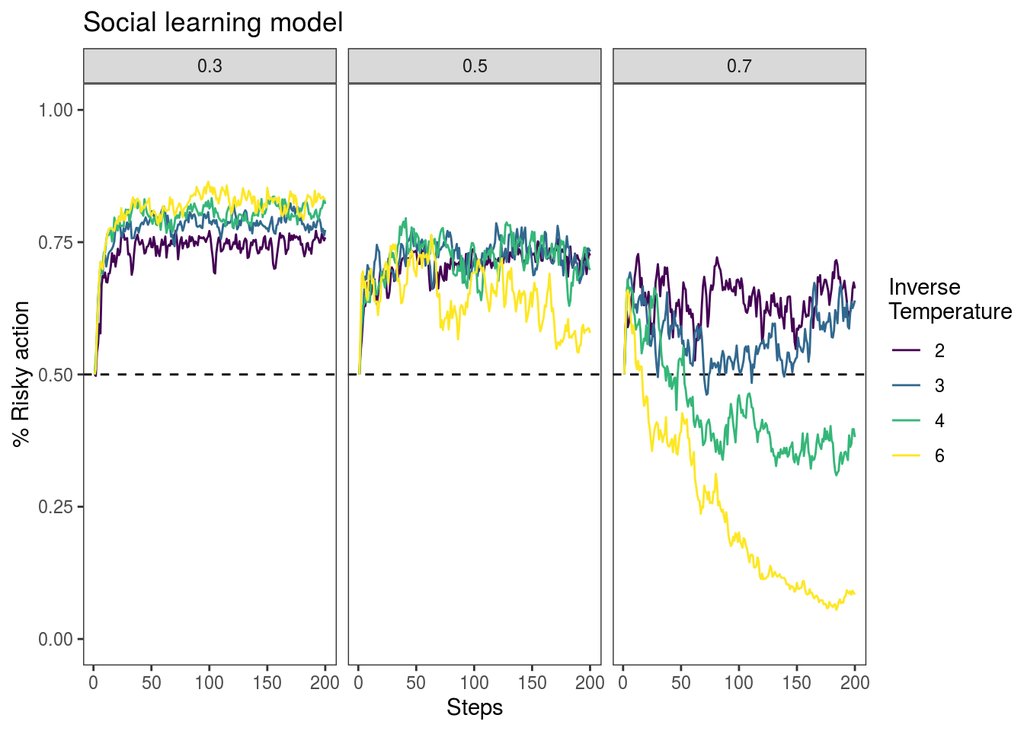

```r
(social_learning_model_data_summarised %>%
  ggplot() +
  geom_hline(yintercept = 0.5, linetype = 'dashed') +
  geom_line(aes(t, riskyChoiceProb_globalMean, colour = as.factor(beta))) +
  scale_colour_viridis_d() +
  ylim(c(0,1))+
  labs(x = 'Steps'
       , y = '% Risky action'
       , colour = 'Inverse\nTemperature'
       , title = 'Social learning model') +
  facet_grid(. ~ alpha) +
  theme_test() +
  NULL -> riskyChoiceProb_plot)
```

Well done. Social learning can rescue reinforcement learners from suboptimal risk-aversion!

After a short break, we will move on to this question: How can we bridge theory and experiments?

[^1]: I am really sad to know 美食楼 Bishoku-rho doesn’t run any more
[^2]: To be fair, the experimental lab rooms in the Centre for Experimental Research in Social Science (CERSS) in Hokkaido University really has an open and clean atmosphere. I highly recommend to visit if you haven’t.
[^3]: There are alternative ways of implementing social influence in reinforcement learning. For example, the “value-shaping” process assumes that social information acts as a pseudo-reward and hence affects the Q-value updating. Though I won’t consider those different models here, it is obviously one of the interesting directions for future studies.